# Station terms for the v6.0 relocation: test on three new clusters

Track B, 2026-11-25. Branch reloc/v6-termtest, code workflow/10_tomography/b4_v6_termtest*.py. Data /wd1/mdenolle_data/reloc_v6/termtest/. A = static station terms (v5.1) + NLL-coherence; B = NLL-SSST stopped at 2 km + NLL-coherence.

## Summary

**Recommendation: B** (NLL-SSST stopped at 2 km, then the coherence stage). The rule was written before the scores: B had to win the held-out-station test in at least 2 of 3 clusters and lose in none. It won in all 3, on P and on S, and no arm put an event above the surface.

### What was tested

Three clusters that share no event with the four earlier sets: 1,000 events in the Puget Lowland (onshore, about 17 km deep), 600 events of the 2015 M5.7 sequence off Cape Mendocino (NC and PB land stations plus 7D and Z5 ocean-bottom seismometers) and 1,200 events of the October 2012 swarm on the western Blanco transform (X9 and 7D ocean-bottom seismometers). Every arm used the same picks (v4.1tc), the same v5.1 grids and the v6-prep code. CC differential times were measured for these clusters with the tested D-B078 code: 42,400 accepted rows in Puget, 22,100 at Mendocino and 38,700 at western Blanco.

### Held-out stations (the leak-free test)

Each arm was rerun three times, each time without one third of the stations, and scored on the CC times at the stations it never saw (-18's scorer). Median misfit (MAD) on the same rows, A then B, with the 95 % interval of B - A:

- Puget: P 85 vs 59 ms (B - A -26 ms, [-32, -20]); S 141 vs 90 ms (-51, [-58, -44]).
- Mendocino: P 67 vs 56 ms (-12, [-15, -8]); S 118 vs 88 ms (-30, [-36, -24]).
- western Blanco: P 149 vs 107 ms (-41, [-46, -37]); S 264 vs 164 ms (-100, [-107, -92]).

### CC fit and depths (full runs)

The median per-pair residual of the CC times favours B in all three clusters: Puget 16.9 vs 14.8 ms, Mendocino 47.1 vs 41.9 ms, western Blanco 41.5 vs 38.6 ms (all intervals exclude 0). The repeaters (true separation about 0.1 km) are mixed: no difference in Puget (0.46 vs 0.53 km), B tighter at Mendocino (1.06 vs 0.38 km), A tighter at western Blanco (0.71 vs 1.77 km; the 2 km SSST pass spreads them there, they sit at 0.81-0.95 km after the 8 and 4 km passes). Depths: against Lange et al. (2026) at western Blanco, B is closer (median |dz| 2.11 vs 1.52 km, 891 events); against PNSN in Puget (345 events, A 1.35, B 1.22 km) and NCSN at Mendocino (39 events, both about 6 km deeper than NCSN, the known offset) there is no material difference. No event is above the surface in any arm.

### Why the gap is large, and how this fits -18's result

The coherence stage of the v6-prep code relocates only events whose error ellipsoid is at most 5 km long. In the held-out runs that is 16-32 % of the located events in Puget, 42-56 % at Mendocino and 0.4-2 % at western Blanco. For every other event A keeps its static-term location and B its SSST location, so most of the difference is static terms against SSST. On the rows where the coherence stage relocated both events in both recipes, B is still better, but by less: Puget P -3.5 ms, S -4.5 ms; Mendocino P -4.5 ms, S -13 ms (intervals exclude 0). Part of B's gain comes from re-estimating station terms on the cluster itself: the first SSST pass (one term per station-phase, CharDist 9999 km) already beats the catalog-wide v5.1 terms (P 91 vs 101 ms in Puget, 69 vs 79 ms at Mendocino, 113 vs 149 ms at western Blanco).

This agrees with -18's four-set result in direction. -18's coherence on SSST stopped at 2 km beat coherence on the static terms by 0 to 9 ms (equal at Axial within 1 ms), without intervals; their coherence stage relocated every event, which is close to the "both relocated" rows here, where the differences are of the same size. It also agrees with -18 that fine SSST passes hurt: here the 2 km pass is already slightly worse than the 4 km pass in all three clusters (held-out P MAD after the 4 km and after the 2 km pass: Puget 64 and 68 ms, Mendocino 43 and 48 ms; at western Blanco the 16 km pass is best, 95 ms against 107 ms at 2 km). That comparison was made after seeing the scores, so it is a lead for a later check, not a result.

### Two things the PI should know

- At Mendocino, SSST alone does better than B on the held-out stations (P 48 vs 56 ms, S 68 vs 88 ms): there the coherence stage moves SSST locations away from what the unseen stations say. In Puget it helps (68 to 59 ms P). B still beats A everywhere, so the choice between A and B does not change.
- The verdict is about the recipe as the v6-prep code runs it (coherence on compact events only, v5.1 grids, cluster-sized search boxes). The v6.0 run will compute SSST on the whole catalog; its first pass then gives catalog-wide terms again, and the local gain comes from the 16 to 2 km passes.

**Recommendation (decision rule written before the scores):** B. Held-out wins: A 0, B 3 of 3 clusters; events above the surface: A 0, B 0.

## Verdict per cluster and criterion

B - A with its 95 % paired bootstrap interval (2,000 resamples). Lower is better for every row. Material: interval excludes 0 and |B - A| at least 5 % of A (0.2 km for depths).

| set | criterion | A | B | B - A [95 %] | better |
| --- | --- | --- | --- | --- | --- |
| puget | 1 held-out MAD P | 84.9 | 59.4 | -25.5 [-32.1, -20.3] | B |
| puget | 1 held-out MAD S | 141.4 | 90.1 | -51.4 [-58.5, -44.0] | B |
| puget | 1 held-out (cluster) |  |  |  | B |
| puget | 2 CC fit (median per-pair residual) | 16.9 | 14.8 | -2.1 [-2.9, -1.4] | B |
| puget | 2 repeater separation (km) | 0.46 | 0.53 | 0.07 [-0.04, 0.21] | no material difference |
| puget | 3 depth \|dz\| A-D (km) | 1.35 | 1.22 | -0.13 [-0.22, 0.03] | no material difference |
| puget | 3 depth \|dz\| A-B (km) | 1.15 | 1.12 | -0.03 [-0.15, 0.07] | no material difference |
| puget | 3 above surface (A / B) | 0 | 0 |  | no material difference |
| mtj | 1 held-out MAD P | 67.1 | 55.6 | -11.6 [-15.0, -8.3] | B |
| mtj | 1 held-out MAD S | 118.2 | 88.0 | -30.2 [-36.2, -23.6] | B |
| mtj | 1 held-out (cluster) |  |  |  | B |
| mtj | 2 CC fit (median per-pair residual) | 47.1 | 41.9 | -5.2 [-7.9, -2.8] | B |
| mtj | 2 repeater separation (km) | 1.06 | 0.38 | -0.68 [-1.29, -0.11] | B |
| mtj | 3 depth \|dz\| A-D (km) | 6.02 | 6.31 | 0.29 [-0.33, 0.70] | no material difference |
| mtj | 3 depth \|dz\| A-B (km) | 6.02 | 6.31 | 0.29 [-0.33, 0.70] | no material difference |
| mtj | 3 above surface (A / B) | 0 | 0 |  | no material difference |
| blancow | 1 held-out MAD P | 148.5 | 107.3 | -41.3 [-46.1, -37.3] | B |
| blancow | 1 held-out MAD S | 263.9 | 163.9 | -99.9 [-107.5, -91.7] | B |
| blancow | 1 held-out (cluster) |  |  |  | B |
| blancow | 2 CC fit (median per-pair residual) | 41.5 | 38.6 | -2.9 [-4.2, -1.7] | B |
| blancow | 2 repeater separation (km) | 0.71 | 1.77 | 1.06 [0.28, 2.57] | A |
| blancow | 3 depth \|dz\| A-D (km) | 2.11 | 1.52 | -0.59 [-0.92, -0.27] | B |
| blancow | 3 depth \|dz\| A-B (km) | 12.64 | 11.08 | -1.56 [-3.97, 1.44] | no material difference |
| blancow | 3 above surface (A / B) | 0 | 0 |  | no material difference |

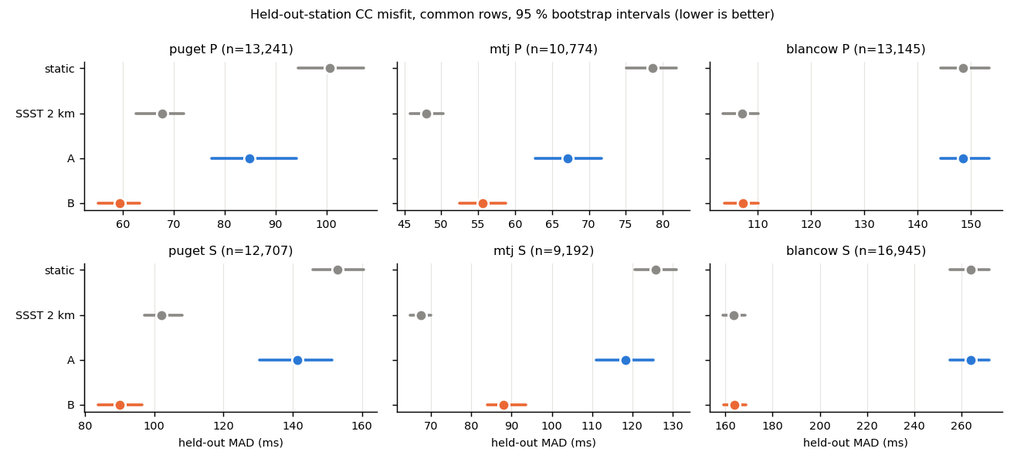

## The three clusters

| set | selection | events | median lat, lon | median depth km | radius km | v5.1 tiers | dates | accepted CC rows |
| --- | --- | --- | --- | --- | --- | --- | --- | --- |
| puget: Puget Lowland (onshore) | Puget/Georgia density peak (8 km count 1025 at 47.771, -122.832); 1000 region events nearest the median epicentre of the 1145 events within 10 km | 1,000 | 47.768, -122.850 | 17.5 | 7.7 | A 176, B 390, C 362, D 72 | 2010-01-02 to 2016-12-20 | 42,420 |
| mtj: Mendocino triple junction (NC land + OBS) | ZBZ family 1536 (682 located events): the 600 nearest its median epicentre | 600 | 40.304, -124.544 | 22.5 | 17.1 | A 256, B 147, C 92, D 105 | 2015-01-14 to 2015-10-25 | 22,131 |
| blancow: western Blanco (offshore OBS) | ZBZ family 427 (1447 located events): the 1200 nearest its median epicentre | 1,200 | 44.159, -129.453 | 8.1 | 4.7 | B 30, C 1073, D 97 | 2012-10-02 to 2013-04-07 | 38,681 |

## 1. Held-out stations

-18's D-B078 scorer (b5_cmp_common.fold_score): 3 station folds, every arm relocated from scratch without the held-out stations' picks and CC rows; residual of each held-out CC dt minus the pair's median training residual; MAD and rms in ms pooled over folds. Common rows: both events located in every arm of the fold. Own rows: each arm's own located events (as -18's tables).

### puget: Puget Lowland (onshore)

| arm | P MAD ms [95 %] | P rms ms [95 %] | S MAD ms [95 %] | S rms ms [95 %] | own rows P / S MAD | located per fold |
| --- | --- | --- | --- | --- | --- | --- |
| static terms alone | 100.6 [94.5, 107.4] | 530.3 [506.6, 554.4] | 152.9 [145.9, 160.6] | 940.7 [898.6, 982.2] | 100.6 / 152.9 | 525 / 988 / 892 |
| SSST it0 (no terms) | 127.2 | 665.1 | 195.4 | 1216.5 | 127.2 / 195.4 | 525 / 988 / 892 |
| SSST it1 (set statics, 9999 km) | 91.0 | 493.7 | 133.4 | 896.4 | 91.0 / 133.4 | 525 / 988 / 892 |
| SSST it2 (16 km) | 75.7 | 496.4 | 113.0 | 883.7 | 75.7 / 113.0 | 525 / 988 / 892 |
| SSST it3 (8 km) | 67.2 | 496.1 | 104.1 | 916.4 | 67.2 / 104.1 | 525 / 988 / 892 |
| SSST it4 (4 km) | 64.2 | 469.9 | 98.4 | 864.1 | 64.2 / 98.4 | 525 / 988 / 892 |
| SSST to 2 km alone (it5) | 67.7 [62.6, 72.0] | 479.3 [456.8, 502.1] | 102.1 [97.2, 108.0] | 882.3 [841.9, 922.8] | 67.7 / 102.1 | 525 / 988 / 892 |
| A: static + coherence | 84.9 [77.4, 94.1] | 533.4 [509.6, 557.7] | 141.4 [130.5, 151.5] | 944.3 [902.3, 985.6] | 84.9 / 141.4 | 525 / 988 / 892 |
| B: SSST to 2 km + coherence | 59.4 [55.1, 63.3] | 479.1 [456.6, 501.5] | 90.1 [83.7, 96.4] | 882.7 [842.4, 923.2] | 59.4 / 90.1 | 525 / 988 / 892 |
| B - A | -25.5 [-32.1, -20.3] | -54.3 [-77.9, -31.0] | -51.4 [-58.5, -44.0] | -61.6 [-98.4, -23.0] |  |  |
| v5.1 catalog (reference; in-sample for held-out) | 38.3 | 83.1 | 53.5 | 104.1 |  |  |

Common rows: P 13,241 rows, 3,943 pairs / S 12,707 rows, 3,846 pairs.

| phase | rows | n | pairs | static | SSST 2 km | A | B | B - A |
| --- | --- | --- | --- | --- | --- | --- | --- | --- |
| P | both events relocated by the coherence stage in A and in B | 3,842 | 852 | 37.8 [35.1, 41.1] | 24.1 [22.1, 26.2] | 19.7 [17.7, 21.6] | 16.2 [14.4, 18.1] | -3.5 [-4.9, -2.0] |
| P | other rows | 9,399 | 3,644 | 161.2 [154.3, 168.7] | 108.8 [103.4, 113.8] | 174.1 [165.8, 181.0] | 107.8 [102.3, 111.8] | -66.3 [-73.9, -58.2] |
| S | both events relocated by the coherence stage in A and in B | 3,075 | 716 | 72.1 [66.5, 77.6] | 44.4 [41.2, 47.7] | 28.9 [26.2, 32.0] | 24.4 [22.3, 27.2] | -4.5 [-7.0, -1.9] |
| S | other rows | 9,632 | 3,543 | 205.4 [197.9, 213.7] | 141.6 [135.1, 148.1] | 237.7 [226.6, 247.2] | 143.8 [136.5, 150.2] | -94.0 [-104.3, -84.1] |

### mtj: Mendocino triple junction (NC land + OBS)

| arm | P MAD ms [95 %] | P rms ms [95 %] | S MAD ms [95 %] | S rms ms [95 %] | own rows P / S MAD | located per fold |
| --- | --- | --- | --- | --- | --- | --- |
| static terms alone | 78.7 [75.0, 81.9] | 216.0 [204.3, 228.9] | 125.8 [120.7, 131.0] | 343.1 [321.7, 365.3] | 78.7 / 125.8 | 472 / 484 / 577 |
| SSST it0 (no terms) | 105.9 | 359.8 | 203.4 | 606.5 | 105.9 / 203.4 | 472 / 484 / 577 |
| SSST it1 (set statics, 9999 km) | 69.2 | 212.6 | 116.0 | 340.8 | 69.2 / 116.0 | 472 / 483 / 577 |
| SSST it2 (16 km) | 52.7 | 153.8 | 76.0 | 243.6 | 52.7 / 76.0 | 472 / 484 / 577 |
| SSST it3 (8 km) | 45.6 | 134.5 | 65.1 | 208.6 | 45.6 / 65.1 | 472 / 484 / 577 |
| SSST it4 (4 km) | 43.3 | 130.9 | 62.4 | 212.9 | 43.3 / 62.4 | 472 / 484 / 577 |
| SSST to 2 km alone (it5) | 48.0 [45.8, 50.3] | 138.7 [129.0, 148.5] | 67.5 [64.8, 70.0] | 216.3 [191.7, 243.1] | 48.0 / 67.5 | 472 / 484 / 577 |
| A: static + coherence | 67.1 [62.7, 71.7] | 213.9 [202.0, 227.2] | 118.2 [111.1, 125.2] | 345.2 [323.9, 367.2] | 67.1 / 118.2 | 472 / 484 / 577 |
| B: SSST to 2 km + coherence | 55.6 [52.5, 58.8] | 161.7 [152.8, 170.7] | 88.0 [84.0, 93.5] | 252.8 [231.9, 275.4] | 55.6 / 88.0 | 472 / 484 / 577 |
| B - A | -11.6 [-15.0, -8.3] | -52.2 [-62.5, -43.0] | -30.2 [-36.2, -23.6] | -92.4 [-111.7, -73.4] |  |  |
| v5.1 catalog (reference; in-sample for held-out) | 58.2 | 130.0 | 86.1 | 157.8 |  |  |

Common rows: P 10,774 rows, 2,062 pairs / S 9,192 rows, 2,003 pairs.

| phase | rows | n | pairs | static | SSST 2 km | A | B | B - A |
| --- | --- | --- | --- | --- | --- | --- | --- | --- |
| P | both events relocated by the coherence stage in A and in B | 7,661 | 1,030 | 66.2 [63.2, 70.3] | 40.0 [38.2, 42.1] | 51.3 [47.1, 55.6] | 46.8 [43.2, 50.1] | -4.5 [-8.0, -1.5] |
| P | other rows | 3,113 | 1,391 | 125.0 [116.9, 132.6] | 77.7 [74.0, 82.8] | 131.1 [123.5, 139.4] | 89.9 [84.1, 95.9] | -41.2 [-49.5, -33.2] |
| S | both events relocated by the coherence stage in A and in B | 5,370 | 959 | 108.2 [103.2, 114.0] | 53.6 [50.9, 56.7] | 90.4 [82.8, 98.5] | 77.3 [71.2, 83.7] | -13.1 [-19.2, -7.1] |
| S | other rows | 3,822 | 1,311 | 165.8 [157.5, 174.7] | 98.8 [94.0, 103.5] | 173.8 [165.8, 182.7] | 110.3 [103.2, 117.0] | -63.4 [-74.3, -53.8] |

### blancow: western Blanco (offshore OBS)

| arm | P MAD ms [95 %] | P rms ms [95 %] | S MAD ms [95 %] | S rms ms [95 %] | own rows P / S MAD | located per fold |
| --- | --- | --- | --- | --- | --- | --- |
| static terms alone | 148.5 [144.3, 153.4] | 406.8 [395.7, 417.6] | 263.9 [255.1, 271.5] | 657.5 [640.3, 676.2] | 148.7 / 264.5 | 1129 / 1024 / 1050 |
| SSST it0 (no terms) | 234.0 | 714.6 | 387.6 | 1075.6 | 234.0 / 387.6 | 1129 / 1018 / 1046 |
| SSST it1 (set statics, 9999 km) | 113.4 | 347.7 | 200.2 | 500.2 | 113.5 / 200.5 | 1129 / 1024 / 1050 |
| SSST it2 (16 km) | 95.1 | 284.0 | 163.3 | 405.3 | 95.2 / 163.6 | 1129 / 1024 / 1050 |
| SSST it3 (8 km) | 96.0 | 292.5 | 154.8 | 389.0 | 96.1 / 155.1 | 1129 / 1024 / 1050 |
| SSST it4 (4 km) | 98.8 | 324.7 | 154.9 | 434.3 | 98.9 / 155.1 | 1129 / 1024 / 1050 |
| SSST to 2 km alone (it5) | 107.1 [103.5, 110.1] | 346.2 [336.6, 355.8] | 163.7 [159.0, 168.5] | 460.6 [445.8, 475.7] | 107.2 / 163.9 | 1129 / 1024 / 1050 |
| A: static + coherence | 148.5 [144.2, 153.3] | 406.8 [395.7, 417.6] | 263.9 [255.1, 271.5] | 657.5 [640.3, 676.2] | 148.7 / 264.6 | 1129 / 1024 / 1050 |
| B: SSST to 2 km + coherence | 107.3 [103.8, 110.2] | 346.3 [336.7, 355.9] | 163.9 [159.2, 168.8] | 460.7 [445.9, 475.7] | 107.4 / 164.2 | 1129 / 1024 / 1050 |
| B - A | -41.3 [-46.1, -37.3] | -60.5 [-71.4, -49.5] | -99.9 [-107.5, -91.7] | -196.8 [-214.8, -178.8] |  |  |
| v5.1 catalog (reference; in-sample for held-out) | 68.0 | 165.5 | 100.1 | 214.8 |  |  |

Common rows: P 13,145 rows, 5,606 pairs / S 16,945 rows, 6,440 pairs.

| phase | rows | n | pairs | static | SSST 2 km | A | B | B - A |
| --- | --- | --- | --- | --- | --- | --- | --- | --- |
| P | both events relocated by the coherence stage in A and in B | 0 | 0 |  |  |  |  |  |
| P | other rows | 13,145 | 5,606 | 148.5 [144.2, 153.5] | 107.1 [103.5, 110.1] | 148.5 [144.2, 153.4] | 107.3 [103.7, 110.3] | -41.3 [-46.0, -37.3] |
| S | both events relocated by the coherence stage in A and in B | 0 | 0 |  |  |  |  |  |
| S | other rows | 16,945 | 6,440 | 263.9 [255.9, 271.7] | 163.7 [158.8, 168.4] | 263.9 [256.0, 271.7] | 163.9 [159.1, 168.6] | -99.9 [-107.3, -92.4] |

## 2. Fit of the CC differential times (full runs)

b4_v6_ssst_metrics.cc_score: per CC row, observed minus predicted differential time (with each arm's own corrections), minus the pair median; 'median per-pair residual' = median |.| (the v6-prep number). Repeaters: CC median >= 0.95 over >= 6 station-phases (qc/<set>_repeaters.csv), median 3-D separation of the pair.

| set | arm | median per-pair residual ms [95 %] | rms ms [95 %] | repeater separation km [95 %] | located | above surface | floor-limited |
| --- | --- | --- | --- | --- | --- | --- | --- |
| puget | static terms alone | 21.7 [20.9, 22.4] | 62.8 [58.6, 67.4] | 0.682 [0.609, 0.733] | 1,000 | 0 | 8 |
|  | SSST to 2 km alone (it5) | 17.9 [17.3, 18.5] | 49.9 [48.8, 50.9] | 0.772 [0.694, 0.843] | 1,000 | 0 | 13 |
|  | A: static + coherence | 16.9 [16.2, 17.7] | 70.6 [59.3, 82.0] | 0.460 [0.387, 0.556] | 1,000 | 0 | 8 |
|  | B: SSST to 2 km + coherence | 14.8 [14.3, 15.4] | 52.2 [50.8, 53.6] | 0.530 [0.379, 0.717] | 1,000 | 0 | 13 |
|  | B-A | -2.1 [-2.9, -1.4] | -18.4 [-29.9, -7.2] | 0.069 [-0.041, 0.208] |  |  |  |
|  | v5.1 repeater separation (km) |  |  | 0.663 |  |  |  |
| mtj | static terms alone | 52.9 [50.9, 55.0] | 118.3 [114.5, 122.1] | 1.707 [1.409, 1.908] | 600 | 0 | 3 |
|  | SSST to 2 km alone (it5) | 31.1 [29.9, 32.2] | 74.7 [71.8, 77.8] | 0.974 [0.687, 1.302] | 600 | 0 | 1 |
|  | A: static + coherence | 47.1 [44.8, 50.0] | 139.2 [133.8, 145.4] | 1.062 [0.506, 1.707] | 600 | 0 | 3 |
|  | B: SSST to 2 km + coherence | 41.9 [39.3, 44.4] | 120.8 [116.1, 125.7] | 0.380 [0.116, 0.824] | 600 | 0 | 1 |
|  | B-A | -5.2 [-7.9, -2.8] | -18.4 [-24.5, -12.9] | -0.682 [-1.287, -0.106] |  |  |  |
|  | v5.1 repeater separation (km) |  |  | 1.564 |  |  |  |
| blancow | static terms alone | 41.5 [40.4, 42.7] | 128.7 [125.9, 131.8] | 0.709 [0.625, 0.843] | 1,200 | 0 | 27 |
|  | SSST to 2 km alone (it5) | 38.5 [37.6, 39.6] | 113.3 [110.8, 116.0] | 1.773 [1.050, 3.298] | 1,200 | 0 | 8 |
|  | A: static + coherence | 41.5 [40.4, 42.7] | 128.7 [126.0, 131.8] | 0.709 [0.625, 0.843] | 1,200 | 0 | 27 |
|  | B: SSST to 2 km + coherence | 38.6 [37.6, 39.6] | 113.4 [110.9, 116.1] | 1.773 [1.050, 3.298] | 1,200 | 0 | 8 |
|  | B-A | -2.9 [-4.2, -1.7] | -15.3 [-17.2, -13.3] | 1.064 [0.279, 2.569] |  |  |  |
|  | v5.1 repeater separation (km) |  |  | 0.695 |  |  |  |

Rows / repeater pairs: puget 36,044 / 279; mtj 20,096 / 41; blancow 29,355 / 72.

## 3. Depths against published catalogs (full runs)

Event pairs fixed per set (the same events for every arm); tiers = v5.1 tier. Depth = true depth km below sea level; reference depths as published (ANSS ComCat depths nominally below sea level; Lange et al. datum read as below sea level, as in the literature report).

| set | reference | tiers | events | A median dz km | B median dz km | A median \|dz\| km | B median \|dz\| km | B - A of median \|dz\| |
| --- | --- | --- | --- | --- | --- | --- | --- | --- |
| puget | PNSN (ANSS ComCat, net uw) | A-D | 345 | 0.33 [0.03, 0.53] | 0.18 [-0.04, 0.41] | 1.35 [1.15, 1.49] | 1.22 [1.06, 1.35] | -0.13 [-0.22, 0.03] |
|  |  |  |  | static 0.25; SSST 0.11; v5.1 0.25 |  | static 1.29; SSST 1.17; v5.1 1.29 |  |  |
| puget | PNSN (ANSS ComCat, net uw) | A-B | 293 | 0.37 [0.10, 0.59] | 0.27 [0.00, 0.50] | 1.15 [1.03, 1.36] | 1.12 [0.99, 1.29] | -0.03 [-0.15, 0.07] |
|  |  |  |  | static 0.30; SSST 0.21; v5.1 0.30 |  | static 1.16; SSST 1.02; v5.1 1.14 |  |  |
| mtj | NCSN (ANSS ComCat, net nc) | A-D | 39 | 6.02 [5.35, 8.40] | 6.31 [5.56, 8.08] | 6.02 [5.35, 8.40] | 6.31 [5.56, 8.08] | 0.29 [-0.33, 0.70] |
|  |  |  |  | static 5.98; SSST 6.31; v5.1 6.02 |  | static 5.98; SSST 6.31; v5.1 6.02 |  |  |
| mtj | NCSN (ANSS ComCat, net nc) | A-B | 39 | 6.02 [5.35, 8.40] | 6.31 [5.56, 8.08] | 6.02 [5.35, 8.40] | 6.31 [5.56, 8.08] | 0.29 [-0.33, 0.70] |
|  |  |  |  | static 5.98; SSST 6.31; v5.1 6.02 |  | static 5.98; SSST 6.31; v5.1 6.02 |  |  |
| blancow | Lange et al. 2026 (absolute) | A-D | 891 | 0.55 [0.34, 0.84] | -0.18 [-0.35, 0.09] | 2.11 [1.79, 2.49] | 1.52 [1.43, 1.66] | -0.59 [-0.92, -0.27] |
|  |  |  |  | static 0.55; SSST -0.18; v5.1 0.55 |  | static 2.11; SSST 1.52; v5.1 2.09 |  |  |
| blancow | Lange et al. 2026 (absolute) | A-B | 21 | 12.64 [11.75, 14.02] | 11.08 [8.67, 14.97] | 12.64 [11.75, 14.02] | 11.08 [8.67, 14.97] | -1.56 [-3.97, 1.44] |
|  |  |  |  | static 12.64; SSST 11.08; v5.1 12.49 |  | static 12.64; SSST 11.08; v5.1 12.49 |  |  |

## Follow-up: where to stop the SSST schedule (16, 8, 4 or 2 km)

**Choice: stop the SSST schedule at 4 km** (9999, 16, 8, 4 km), by the rule written in RESUME.md before any run of this test. With the coherence stage, the held-out score (MAD P + MAD S, mean of the two clusters) is 81.0 ms at 16 km, 78.4 at 8 km, 76.8 at 4 km and 80.2 at 2 km. The next coarser stop, 8 km, is worse than 4 km by 1.6 ms (95 % interval 0.3 to 2.7 ms), so the rule keeps 4 km. Stopping at 2 km costs 3.4 ms (1.8 to 4.6) against 4 km. The gaps are small, 2 to 5 % of the score, but they point the same way as the post-hoc hint from the first three clusters.

### Clusters

Two new clusters that share no event with the seven earlier ones: 700 events in the Strait of Georgia (onshore, about 15 km deep, CN, PB, UW and TA stations) and 800 events of the 2014 M6.8 Gorda plate sequence (ZBZ family 1162, Z5 and 7D ocean-bottom seismometers with NC, PB, BK and TA land stations). CC data came from the same tested code: 42,000 accepted rows at Georgia and 23,400 at Gorda. Each run used one SSST chain, with oct-trees saved after the 16, 8, 4 and 2 km passes and the coherence stage run on each.

### Held-out stations, per cluster

- Georgia, with coherence, P / S MAD: 20.1 / 31.5 ms at 16 km, 20.2 / 30.8 at 8 km, 19.2 / 29.6 at 4 km, 20.4 / 31.1 at 2 km. The 4 km stop is lowest on both phases.
- Gorda, with coherence: 48.1 / 62.2 ms at 16 km, 46.7 / 59.2 at 8 km, 47.1 / 57.7 at 4 km, 49.2 / 59.7 at 2 km. The curve is flat between 8 and 4 km, and 2 and 16 km are both worse.

### Does the coherence stage help?

At Georgia it helps a lot, at every stop: P drops by about 15 ms (34.0 to 19.2 ms at 4 km) and S by about 21 ms, to values below those of the v5.1 catalog, which saw the held-out stations (26.5 / 43.4 ms). At Gorda it changes nothing that matters (-0.4 to +1.2 ms). There the stage relocates few events, because most Gorda events have error ellipsoids longer than 5 km: 0.5 to 22 % of the located events in the fold runs, against 41 to 53 % at Georgia. Over the five independent clusters tested today, coherence helped where it relocates many events (Puget, Georgia), hurt at Mendocino, and was neutral where it relocates few (Gorda, western Blanco).

### Other criteria (full runs)

- CC fit (median per-pair residual): Georgia lowest at 4 km with coherence (13.8 ms; 14.0 at 8 km, 14.3 at 2 km). At Gorda the 16 and 8 km stops fit best (18.8 and 18.6 ms), 4 km is at 20.1 ms and 2 km at 25.9 ms, so the 2 km stop is clearly worse.
- Repeaters: Georgia 168 pairs, median separation 0.24 km at 4 km with coherence (0.26 to 0.29 km at the other stops, 0.58 km in v5.1). Gorda has only 15 pairs; its intervals overlap at every stop.
- Depths: no stop is distinguishable from another. All arms sit about 2.7 km deeper than PNSN at Georgia (138 events; v5.1 2.4 km) and about 6 km deeper than NCSN at Gorda (27 events, the known Mendocino-area offset).
- Above the surface: 0 events in every arm. Floor-limited: 9 to 16 events at Georgia, 0 or 1 at Gorda.

**Choice by the rule written before the scores:** stop at **4 km**. Lowest score: 4 km; 8 km worse than 4 km (interval of the difference excludes 0).

Score S(d) = mean over the two clusters of held-out MAD P + MAD S (ms) with the coherence stage; 95 % paired bootstrap intervals (2,000 resamples of event pairs within each cluster). Rule: lowest S(d); the next coarser stop is taken if the interval of their difference includes 0.

| stop | S(d) with coherence [95 %] | S(d) - S(best) [95 %] | S(d) without coherence [95 %] |
| --- | --- | --- | --- |
| 16 km | 81.0 [77.8, 83.7] | 4.1 [2.3, 5.3] | 98.8 [95.6, 101.9] |
| 8 km | 78.4 [75.7, 81.4] | 1.6 [0.3, 2.7] | 95.7 [92.8, 98.8] |
| 4 km | 76.8 [74.5, 79.9] | best | 94.9 [92.1, 97.9] |
| 2 km | 80.2 [77.4, 83.3] | 3.4 [1.8, 4.6] | 98.7 [95.6, 101.8] |

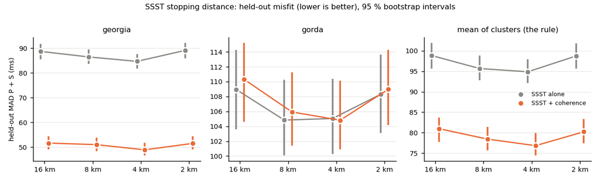

| set | selection | events | median lat, lon | median depth km | radius km | v5.1 tiers | dates |
| --- | --- | --- | --- | --- | --- | --- | --- |
| georgia: Strait of Georgia (onshore) | Strait of Georgia peak (48.624, -123.075); 700 region events nearest the median epicentre of the 715 events within 10 km | 700 | 48.618, -123.065 | 14.6 | 9.0 | A 239, B 182, C 146, D 133 | 2010-01-01 to 2016-12-11 |
| gorda: Gorda plate interior (OBS + land) | ZBZ family 1162 (2358 located events): the 800 nearest its median epicentre | 800 | 40.686, -125.358 | 26.6 | 9.2 | A 24, B 396, C 312, D 68 | 2014-03-10 to 2015-08-04 |

### georgia: Strait of Georgia (onshore)

| arm | held-out P MAD ms [95 %] | held-out S MAD ms [95 %] | P + S [95 %] | own rows P / S | located per fold |
| --- | --- | --- | --- | --- | --- |
| SSST stopped at 16 km | 35.8 [34.2, 37.4] | 52.9 [50.9, 54.9] | 88.7 [85.6, 91.8] | 35.8 / 52.9 | 686 / 551 / 595 |
| SSST stopped at 8 km | 35.0 [33.6, 36.5] | 51.5 [49.7, 53.4] | 86.5 [83.6, 89.5] | 35.0 / 51.5 | 687 / 551 / 595 |
| SSST stopped at 4 km | 34.0 [32.6, 35.6] | 50.7 [48.8, 52.5] | 84.7 [81.8, 87.6] | 34.0 / 50.7 | 687 / 551 / 595 |
| SSST stopped at 2 km | 35.5 [33.8, 37.1] | 53.7 [51.8, 55.5] | 89.1 [86.0, 92.2] | 35.5 / 53.7 | 687 / 551 / 595 |
| SSST stopped at 16 km + coherence | 20.1 [18.9, 21.6] | 31.5 [29.9, 33.1] | 51.6 [49.1, 54.4] | 20.1 / 31.5 | 686 / 551 / 595 |
| SSST stopped at 8 km + coherence | 20.2 [18.9, 21.7] | 30.8 [29.2, 32.4] | 51.0 [48.3, 53.9] | 20.2 / 30.8 | 687 / 551 / 595 |
| SSST stopped at 4 km + coherence | 19.2 [18.1, 20.6] | 29.6 [28.3, 31.2] | 48.9 [46.7, 51.7] | 19.2 / 29.6 | 687 / 551 / 595 |
| SSST stopped at 2 km + coherence | 20.4 [19.2, 21.9] | 31.1 [29.7, 32.8] | 51.5 [49.1, 54.4] | 20.4 / 31.1 | 687 / 551 / 595 |
| v5.1 catalog (in-sample for held-out) | 26.5 | 43.4 |  |  |  |

Common rows: P 14,453, S 20,359, 4,525 event pairs.

Does the coherence stage help? Held-out MAD with coherence minus without, same stop (negative = coherence helps).

| stop | P: coh - SSST ms [95 %] | S: coh - SSST ms [95 %] |
| --- | --- | --- |
| 16 km | -15.7 [-17.1, -14.3] | -21.4 [-23.3, -19.6] |
| 8 km | -14.8 [-16.1, -13.5] | -20.7 [-22.6, -18.8] |
| 4 km | -14.8 [-16.0, -13.4] | -21.0 [-22.8, -19.2] |
| 2 km | -15.1 [-16.4, -13.6] | -22.6 [-24.4, -20.7] |

| arm (full run) | CC median per-pair residual ms [95 %] | CC rms ms [95 %] | repeater separation km [95 %] (168 pairs) | located | above surface | floor-limited |
| --- | --- | --- | --- | --- | --- | --- |
| SSST stopped at 16 km | 22.5 [21.7, 23.2] | 56.7 [55.6, 57.8] | 0.625 [0.582, 0.735] | 700 | 0 | 16 |
| SSST stopped at 8 km | 21.8 [21.1, 22.4] | 55.5 [54.4, 56.6] | 0.646 [0.561, 0.701] | 700 | 0 | 13 |
| SSST stopped at 4 km | 21.6 [21.0, 22.2] | 54.7 [53.6, 55.9] | 0.648 [0.546, 0.736] | 700 | 0 | 12 |
| SSST stopped at 2 km | 22.8 [22.2, 23.5] | 56.4 [55.3, 57.6] | 0.684 [0.582, 0.783] | 700 | 0 | 9 |
| SSST stopped at 16 km + coherence | 14.1 [13.5, 14.7] | 53.7 [52.1, 55.5] | 0.281 [0.202, 0.364] | 700 | 0 | 16 |
| SSST stopped at 8 km + coherence | 14.0 [13.4, 14.5] | 52.9 [51.2, 54.5] | 0.264 [0.202, 0.351] | 700 | 0 | 13 |
| SSST stopped at 4 km + coherence | 13.8 [13.3, 14.4] | 51.5 [49.9, 53.1] | 0.237 [0.192, 0.334] | 700 | 0 | 12 |
| SSST stopped at 2 km + coherence | 14.3 [13.7, 15.0] | 52.9 [51.3, 54.5] | 0.287 [0.225, 0.363] | 700 | 0 | 9 |
| v5.1 catalog |  |  | 0.583 |  |  |  |

Depths against PNSN (ANSS ComCat, net uw) (138 paired events; tiers = v5.1 tier).

| tiers | arm | events | median dz km [95 %] | median \|dz\| km [95 %] |
| --- | --- | --- | --- | --- |
| A-D | SSST stopped at 16 km | 138 | 2.68 [2.40, 2.80] | 2.72 [2.49, 2.82] |
| A-D | SSST stopped at 8 km | 138 | 2.73 [2.49, 2.82] | 2.75 [2.54, 2.84] |
| A-D | SSST stopped at 4 km | 138 | 2.70 [2.54, 2.88] | 2.77 [2.59, 2.89] |
| A-D | SSST stopped at 2 km | 138 | 2.77 [2.55, 2.93] | 2.79 [2.60, 2.95] |
| A-D | SSST stopped at 16 km + coherence | 138 | 2.63 [2.48, 2.85] | 2.65 [2.51, 2.90] |
| A-D | SSST stopped at 8 km + coherence | 138 | 2.68 [2.48, 2.85] | 2.71 [2.55, 2.95] |
| A-D | SSST stopped at 4 km + coherence | 138 | 2.71 [2.48, 2.88] | 2.77 [2.55, 2.98] |
| A-D | SSST stopped at 2 km + coherence | 138 | 2.74 [2.55, 2.95] | 2.75 [2.61, 2.97] |
| A-D | v5.1 catalog | 138 | 2.36 | 2.45 |
| A-B | SSST stopped at 16 km | 127 | 2.59 [2.36, 2.78] | 2.67 [2.45, 2.80] |
| A-B | SSST stopped at 8 km | 127 | 2.60 [2.43, 2.81] | 2.73 [2.51, 2.81] |
| A-B | SSST stopped at 4 km | 127 | 2.66 [2.51, 2.85] | 2.70 [2.53, 2.88] |
| A-B | SSST stopped at 2 km | 127 | 2.73 [2.48, 2.91] | 2.76 [2.60, 2.92] |
| A-B | SSST stopped at 16 km + coherence | 127 | 2.59 [2.41, 2.79] | 2.63 [2.48, 2.85] |
| A-B | SSST stopped at 8 km + coherence | 127 | 2.60 [2.46, 2.83] | 2.67 [2.48, 2.85] |
| A-B | SSST stopped at 4 km + coherence | 127 | 2.67 [2.45, 2.88] | 2.67 [2.48, 2.88] |
| A-B | SSST stopped at 2 km + coherence | 127 | 2.70 [2.47, 2.88] | 2.73 [2.59, 2.88] |
| A-B | v5.1 catalog | 127 | 2.32 | 2.39 |

### gorda: Gorda plate interior (OBS + land)

| arm | held-out P MAD ms [95 %] | held-out S MAD ms [95 %] | P + S [95 %] | own rows P / S | located per fold |
| --- | --- | --- | --- | --- | --- |
| SSST stopped at 16 km | 48.0 [45.0, 51.0] | 61.0 [57.1, 64.7] | 109.0 [103.6, 114.3] | 48.0 / 61.0 | 651 / 772 / 760 |
| SSST stopped at 8 km | 46.8 [43.5, 49.8] | 58.1 [55.1, 61.9] | 104.8 [100.1, 110.3] | 46.8 / 58.1 | 651 / 772 / 760 |
| SSST stopped at 4 km | 46.9 [44.1, 50.1] | 58.1 [55.0, 62.1] | 105.0 [100.3, 110.4] | 46.9 / 58.1 | 651 / 772 / 760 |
| SSST stopped at 2 km | 48.8 [45.5, 52.0] | 59.5 [56.2, 63.1] | 108.3 [103.1, 113.6] | 48.8 / 59.5 | 651 / 772 / 760 |
| SSST stopped at 16 km + coherence | 48.1 [45.0, 51.3] | 62.2 [58.0, 65.4] | 110.3 [104.6, 115.2] | 48.1 / 62.2 | 651 / 772 / 760 |
| SSST stopped at 8 km + coherence | 46.7 [43.7, 49.9] | 59.2 [56.3, 62.9] | 105.9 [101.4, 111.2] | 46.7 / 59.2 | 651 / 772 / 760 |
| SSST stopped at 4 km + coherence | 47.1 [44.6, 50.2] | 57.7 [55.1, 61.6] | 104.8 [100.9, 110.1] | 47.1 / 57.7 | 651 / 772 / 760 |
| SSST stopped at 2 km + coherence | 49.2 [46.1, 52.5] | 59.7 [56.5, 63.3] | 109.0 [104.1, 114.2] | 49.2 / 59.7 | 651 / 772 / 760 |
| v5.1 catalog (in-sample for held-out) | 31.1 | 42.4 |  |  |  |

Common rows: P 8,586, S 10,139, 3,709 event pairs.

Does the coherence stage help? Held-out MAD with coherence minus without, same stop (negative = coherence helps).

| stop | P: coh - SSST ms [95 %] | S: coh - SSST ms [95 %] |
| --- | --- | --- |
| 16 km | 0.2 [-0.4, 0.7] | 1.2 [0.1, 2.2] |
| 8 km | -0.0 [-0.6, 0.7] | 1.1 [0.1, 2.1] |
| 4 km | 0.2 [-0.4, 0.9] | -0.4 [-1.3, 0.7] |
| 2 km | 0.5 [-0.4, 1.6] | 0.2 [-1.1, 1.5] |

| arm (full run) | CC median per-pair residual ms [95 %] | CC rms ms [95 %] | repeater separation km [95 %] (15 pairs) | located | above surface | floor-limited |
| --- | --- | --- | --- | --- | --- | --- |
| SSST stopped at 16 km | 18.3 [17.5, 19.2] | 86.1 [82.4, 90.6] | 0.740 [0.413, 0.920] | 800 | 0 | 1 |
| SSST stopped at 8 km | 18.1 [17.3, 19.0] | 85.8 [81.9, 90.2] | 0.537 [0.374, 1.021] | 800 | 0 | 1 |
| SSST stopped at 4 km | 20.1 [19.2, 21.0] | 86.4 [82.9, 90.1] | 0.565 [0.434, 1.034] | 800 | 0 | 0 |
| SSST stopped at 2 km | 26.6 [25.6, 27.6] | 86.2 [83.7, 88.7] | 0.782 [0.460, 2.311] | 800 | 0 | 0 |
| SSST stopped at 16 km + coherence | 18.8 [18.0, 19.8] | 90.0 [85.9, 94.4] | 0.740 [0.285, 0.986] | 800 | 0 | 1 |
| SSST stopped at 8 km + coherence | 18.6 [17.7, 19.5] | 89.8 [85.6, 94.3] | 0.537 [0.213, 1.021] | 800 | 0 | 1 |
| SSST stopped at 4 km + coherence | 20.1 [19.1, 21.0] | 92.0 [88.4, 95.9] | 0.447 [0.220, 0.982] | 800 | 0 | 0 |
| SSST stopped at 2 km + coherence | 25.9 [24.9, 27.1] | 127.0 [113.3, 140.9] | 0.538 [0.129, 1.888] | 800 | 0 | 0 |
| v5.1 catalog |  |  | 0.818 |  |  |  |

Depths against NCSN (ANSS ComCat, net nc) (27 paired events; tiers = v5.1 tier).

| tiers | arm | events | median dz km [95 %] | median \|dz\| km [95 %] |
| --- | --- | --- | --- | --- |
| A-D | SSST stopped at 16 km | 27 | 6.13 [4.50, 12.79] | 6.36 [4.97, 12.79] |
| A-D | SSST stopped at 8 km | 27 | 5.89 [4.72, 13.56] | 6.13 [5.17, 13.56] |
| A-D | SSST stopped at 4 km | 27 | 6.63 [5.40, 13.30] | 6.98 [5.80, 13.30] |
| A-D | SSST stopped at 2 km | 27 | 7.73 [4.64, 13.46] | 8.01 [6.26, 13.46] |
| A-D | SSST stopped at 16 km + coherence | 27 | 6.13 [4.50, 12.79] | 6.36 [4.90, 12.79] |
| A-D | SSST stopped at 8 km + coherence | 27 | 5.89 [4.72, 13.56] | 6.13 [5.19, 13.56] |
| A-D | SSST stopped at 4 km + coherence | 27 | 6.19 [3.32, 12.53] | 6.35 [5.33, 12.53] |
| A-D | SSST stopped at 2 km + coherence | 27 | 6.45 [3.00, 8.58] | 6.82 [4.72, 8.58] |
| A-D | v5.1 catalog | 27 | 7.38 | 8.57 |
| A-B | SSST stopped at 16 km | 16 | 5.04 [3.64, 14.25] | 5.04 [3.64, 14.25] |
| A-B | SSST stopped at 8 km | 16 | 5.21 [3.35, 13.56] | 5.21 [3.35, 13.56] |
| A-B | SSST stopped at 4 km | 16 | 6.37 [3.28, 13.30] | 6.37 [3.28, 13.30] |
| A-B | SSST stopped at 2 km | 16 | 6.70 [3.14, 13.46] | 6.70 [3.14, 13.46] |
| A-B | SSST stopped at 16 km + coherence | 16 | 5.00 [3.66, 14.26] | 5.00 [3.66, 14.26] |
| A-B | SSST stopped at 8 km + coherence | 16 | 5.22 [3.52, 13.56] | 5.22 [3.52, 13.56] |
| A-B | SSST stopped at 4 km + coherence | 16 | 5.78 [3.32, 13.74] | 5.78 [3.32, 13.74] |
| A-B | SSST stopped at 2 km + coherence | 16 | 6.63 [3.29, 13.60] | 6.63 [3.29, 13.60] |
| A-B | v5.1 catalog | 16 | 5.26 | 5.26 |

## Method

### Why this test

On 2026-11-25 at 14:29 the PI chose a test over a decision between two station-term recipes for the v6.0 NonLinLoc relocation. Recipe A is the v5.1 static station terms followed by the NLL-coherence stage. Recipe B is NLL-SSST with the CharDist schedule 9999, 16, 8, 4, 2 km (it stops at 2 km) followed by the same coherence stage. The two earlier tests (the v6-prep test and -18's D-B078 comparison) used the same four clusters (axial, blanco, msh, jdf), so this test uses three clusters that share no event with them.

### Clusters

Clusters come from the v5.1 clustering (events_zbz_v51.csv.gz, families_zbz_v51.csv) and are cut like -18's sets: the located events nearest the median epicentre. Puget Lowland has no ZBZ family above 205 events, so the onshore set is spatial: the densest spot of v5.1 epicentres in the Puget/Georgia region (Kitsap Peninsula, about 17 km deep), 1,000 events. The Mendocino set is family 1536, the 2015-01-28 M5.7 offshore Cape Mendocino sequence, recorded by NC, BK, PB and TA land stations and by the 7D and Z5 ocean-bottom seismometers of Cascadia Initiative year 4 (600 events). The offshore set is family 427, the October 2012 swarm on the western Blanco transform, recorded by the Blanco OBS experiment (X9) and 7D (1,200 events).

### Relocation

Every arm runs the v6-prep code (b4_v6_ssst.py) unchanged in what it computes: the clock-corrected picks v4.1tc (md5 checked), a2_make_obs.py, the v5.1 travel-time grids (the 1 km grid, or the 2 km wide grid for a station whose 1 km grid does not cover the search box), a search box of the set's epicentres plus 30 km and z' from -5 to 80 km, NLLoc with the v5.1 settings (LOCGAU 0.2 s, at least 5 phases, the merged-surface floor), Loc2ssst with the v6-prep LSPHSTAT and WeightFloor, and the coherence stage of b4_v6_ssst.coherence_run. That stage relocates only events whose 68 % ellipsoid is at most 5 km long (Len3), by stacking the oct-tree pdfs of the event and of its partners with pair coherence of at least 0.5; the other events keep their previous location. Pair coherence is the median cc_max of the pair's measured CC rows (at least 3 rows). The static arm is the static_oct run (static terms, oct-trees saved): in the v6-prep axial run its locations are identical to the run without oct-trees.

### CC data

The CC differential times come from the tested D-B078 code (tomo/cc-dt 2d033ec6), with its parameters and the 3-15 Hz band that D-B093 uses for every block except Mount St Helens. Only the output folder and the set names change. Snippets that the D-B093 all-family job had already read were copied from its cache (read only); the others were read from pnwstore with the same reader. NC and BK snippets (Mendocino) come from the D-B093 NCEDC cache. Rows that straddle a confirmed D-B090 clock epoch (MH07.XD, MG07.XD) are flagged as in D-B078.

### Criterion 1: held-out stations

This is -18's protocol and scorer (b5_cmp_common.fold_score from tomo/b5 b0dffcdd). The stations with picks in a set are dealt into 3 folds with a fixed seed. For each fold every arm is rerun from the beginning without the picks of that fold's stations, and the coherence stage uses no CC row at those stations, so no position or pair weight has seen the held-out stations. The held-out CC differential times are then predicted from each arm's positions in the v5.1 grids; each residual has the pair's median training residual removed, which cancels the origin-time offset. MAD and rms are pooled over the folds. The one change from -18's scorer: the prediction uses the grid NLLoc used for that station (1 km or 2 km wide grid) instead of always the 1 km grid, because in the western Blanco set 91 of 143 station-phases have no 1 km grid over the box and -18's lookup would be clipped at the grid edge. Arms are compared on the rows whose two events are located in every arm of the fold.

### Criterion 2: fit of the CC times

On the full runs (all stations), the median per-pair residual of b4_v6_ssst_metrics.cc_score: for each accepted CC row, the observed minus the predicted differential arrival time with each arm's own corrections, minus the pair's median, then the median absolute value. This criterion is not independent of recipe B, whose SSST corrections are fitted to the same stations, and it does not test the coherence stage against data it has not seen. The repeater check takes the CC repeaters (median CC at least 0.95 over at least 6 station-phases), whose true separations are about 0.1 km, and reports the median 3-D distance each arm gives them.

### Criterion 3: depths

Full runs only, against published catalogs: Lange et al. (2026) absolute OBS locations for western Blanco (the pair table of b4_lit_paired.py), PNSN (ANSS ComCat net uw) for Puget, NCSN (net nc) for Mendocino. ComCat events are paired one-to-one with the v5.1 events, greedy by origin-time difference then distance (Puget 2 s and 10 km, Mendocino 3 s and 20 km). The same events are used for every arm. Also counted: events above the merged solid surface (must be 0) and events at the NLLoc floor.

### Statistics and decision rule

Intervals are 95 % percentile intervals from 2,000 paired bootstrap resamples (event pairs for criteria 1 and 2, with all of a pair's rows kept together; events for criterion 3). A difference is material when the interval of B - A excludes zero and the difference is at least 5 % of A (0.2 km for depths). The rule, written before any score of these runs: B is recommended only if it is materially better on held-out stations in at least 2 of the 3 clusters, materially worse in none, and puts no event above the surface; A on the mirror condition; otherwise "no material difference", and then A because it is simpler. Criteria 2 and 3 can only veto: a winner of criterion 1 that loses materially on both of them in 2 clusters is not recommended.